# Final project-Copy1

### Part 1: Data cleaning & EDA

```python
import pandas as pd
import numpy as np
from scipy.stats import zscore
import matplotlib.pyplot as plt
import seaborn as sns
from sklearn import decomposition
from sklearn.model_selection import train_test_split
from sklearn.pipeline import Pipeline
from sklearn import preprocessing
from sklearn.preprocessing import StandardScaler
from factor_analyzer import FactorAnalyzer
from factor_analyzer.factor_analyzer import calculate_bartlett_sphericity
from factor_analyzer.factor_analyzer import calculate_kmo
```

```python
# By not adding "index_col=0", we reset an index of the data frame
df=pd.read_csv('telcom churn.csv')
```

```python
df.head()
```

|  | customerID | gender | SeniorCitizen | Partner | Dependents | tenure | PhoneService | MultipleLines | InternetService | OnlineSecurity | ... | DeviceProtection | TechSupport | StreamingTV | StreamingMovies | Contract | PaperlessBilling | PaymentMethod | MonthlyCharges | TotalCharges | Churn |
| --- | --- | --- | --- | --- | --- | --- | --- | --- | --- | --- | --- | --- | --- | --- | --- | --- | --- | --- | --- | --- | --- |
| 0 | 7590-VHVEG | Female | 0 | Yes | No | 1 | No | No phone service | DSL | No | ... | No | No | No | No | Month-to-month | Yes | Electronic check | 29.85 | 29.85 | No |
| 1 | 5575-GNVDE | Male | 0 | No | No | 34 | Yes | No | DSL | Yes | ... | Yes | No | No | No | One year | No | Mailed check | 56.95 | 1889.5 | No |
| 2 | 3668-QPYBK | Male | 0 | No | No | 2 | Yes | No | DSL | Yes | ... | No | No | No | No | Month-to-month | Yes | Mailed check | 53.85 | 108.15 | Yes |
| 3 | 7795-CFOCW | Male | 0 | No | No | 45 | No | No phone service | DSL | Yes | ... | Yes | Yes | No | No | One year | No | Bank transfer (automatic) | 42.30 | 1840.75 | No |
| 4 | 9237-HQITU | Female | 0 | No | No | 2 | Yes | No | Fiber optic | No | ... | No | No | No | No | Month-to-month | Yes | Electronic check | 70.70 | 151.65 | Yes |

5 rows × 21 columns

```python
# We dropped the originial long and unuseful index
df.drop(columns=['customerID'],inplace=True)
```

```python
#Inspecting whether there is any missing value
df.info()
```

```
<class 'pandas.core.frame.DataFrame'>
RangeIndex: 7043 entries, 0 to 7042
Data columns (total 20 columns):
gender              7043 non-null object
SeniorCitizen       7043 non-null int64
Partner             7043 non-null object
Dependents          7043 non-null object
tenure              7043 non-null int64
PhoneService        7043 non-null object
MultipleLines       7043 non-null object
InternetService     7043 non-null object
OnlineSecurity      7043 non-null object
OnlineBackup        7043 non-null object
DeviceProtection    7043 non-null object
TechSupport         7043 non-null object
StreamingTV         7043 non-null object
StreamingMovies     7043 non-null object
Contract            7043 non-null object
PaperlessBilling    7043 non-null object
PaymentMethod       7043 non-null object
MonthlyCharges      7043 non-null float64
TotalCharges        7043 non-null object
Churn               7043 non-null object
dtypes: float64(1), int64(2), object(17)
memory usage: 1.1+ MB
```

There is no missing value! Lucky for us. The next step is to transform our categorical variables. The first step is to inspect how many values are there under each category.

```python
# First, we need to filter out categorical variables
cat_var=['gender','Partner','Dependents','PhoneService','MultipleLines','InternetService','OnlineSecurity','OnlineBackup',
        'DeviceProtection','TechSupport','StreamingTV','StreamingMovies','Contract','PaperlessBilling','PaymentMethod',
        'Churn']

# Note that there is one "fake" string variable: TotalCharges, we first transform it into numeric values by recalculate it by doing:tenure*MonthlyCharges
df['TotalCharges']=df['tenure']*df['MonthlyCharges']

# Then let's inspect what values those categorical variables have
for i in cat_var:
    print(str(i)+':'+ str(df[i].unique()))
```

```
gender:['Female' 'Male']
Partner:['Yes' 'No']
Dependents:['No' 'Yes']
PhoneService:['No' 'Yes']
MultipleLines:['No phone service' 'No' 'Yes']
InternetService:['DSL' 'Fiber optic' 'No']
OnlineSecurity:['No' 'Yes' 'No internet service']
OnlineBackup:['Yes' 'No' 'No internet service']
DeviceProtection:['No' 'Yes' 'No internet service']
TechSupport:['No' 'Yes' 'No internet service']
StreamingTV:['No' 'Yes' 'No internet service']
StreamingMovies:['No' 'Yes' 'No internet service']
Contract:['Month-to-month' 'One year' 'Two year']
PaperlessBilling:['Yes' 'No']
PaymentMethod:['Electronic check' 'Mailed check' 'Bank transfer (automatic)'
 'Credit card (automatic)']
Churn:['No' 'Yes']
```

```python
# we can see from the variables above that we can categorize those "No xxx(such as internet) service" to "No". For example, if
# an observation did not subscribe phone service, then he can't have multiplelines service

#Then we will have 14 binary categorical variables, let's first transform them, we assign positive answer as 1, negative as 0.
# For gender, we assign Male as 1 and Female as 0
def cateTransformer(colname):
    for i in df[colname].unique():
        if i == 'Yes':
            df[colname].replace(i,1,inplace=True)
        if i != 'Yes':
            df[colname].replace(i,0,inplace=True)
# URL:https://pandas.pydata.org/pandas-docs/stable/reference/api/pandas.DataFrame.replace.html
```

```python
#Transfer them one by one
df['gender'].replace('Female',0,inplace=True)
df['gender'].replace('Male',1,inplace=True)
binarycate=['Partner','Dependents','PhoneService','MultipleLines','OnlineSecurity','OnlineBackup',
        'DeviceProtection','TechSupport','StreamingTV','StreamingMovies','PaperlessBilling','Churn']
for i in binarycate:
            cateTransformer(i)
```

```python
for i in cat_var:
    print(str(i)+':'+ str(df[i].unique()))
```

```
gender:[0 1]
Partner:[1 0]
Dependents:[0 1]
PhoneService:[0 1]
MultipleLines:[0 1]
InternetService:['DSL' 'Fiber optic' 'No']
OnlineSecurity:[0 1]
OnlineBackup:[1 0]
DeviceProtection:[0 1]
TechSupport:[0 1]
StreamingTV:[0 1]
StreamingMovies:[0 1]
Contract:['Month-to-month' 'One year' 'Two year']
PaperlessBilling:[1 0]
PaymentMethod:['Electronic check' 'Mailed check' 'Bank transfer (automatic)'
 'Credit card (automatic)']
Churn:[0 1]
```

```python
# Half way through, let's deal with the 3 rest
# For internet service, we will replace it with two columns: DSL and Fiber optic
df['DSL']=0
df.loc[df['InternetService']=='DSL',['DSL']]=1
df['Fiber optic']=0
df.loc[df['InternetService']=='Fiber optic',['Fiber optic']]=1

# For Contract, we will add two more columns: one year and two year
df['oneY_contr']=0
df.loc[df['Contract']=='One year',['oneY_contr']]=1
df['twoY_contr']=0
df.loc[df['Contract']=='Two year',['twoY_contr']]=1

# For payment method, let's find out the default by looking at the most common payment method
print(df.groupby('PaymentMethod').count())
# As most people pay by electronic check, we set it as the default by creating three columns for the rest three methods
df['CreCard']=0 #CreCard for credit card
df.loc[df['PaymentMethod']=='Credit card (automatic)',['CreCard']]=1
df['Banktran']=0 #Banktran for bank transfer
df.loc[df['PaymentMethod']=='Bank transfer (automatic)',['Banktran']]=1
df['Mail']=0 #Mail for Mailed check
df.loc[df['PaymentMethod']=='Mailed check',['Mail']]=1
```

```
                           gender  SeniorCitizen  Partner  Dependents  tenure  \
PaymentMethod
Bank transfer (automatic)    1544           1544     1544        1544    1544
Credit card (automatic)      1522           1522     1522        1522    1522
Electronic check             2365           2365     2365        2365    2365
Mailed check                 1612           1612     1612        1612    1612

                           PhoneService  MultipleLines  InternetService  \
PaymentMethod
Bank transfer (automatic)          1544           1544             1544
Credit card (automatic)            1522           1522             1522
Electronic check                   2365           2365             2365
Mailed check                       1612           1612             1612

                           OnlineSecurity  OnlineBackup  ...  StreamingMovies  \
PaymentMethod                                            ...
Bank transfer (automatic)            1544          1544  ...             1544
Credit card (automatic)              1522          1522  ...             1522
Electronic check                     2365          2365  ...             2365
Mailed check                         1612          1612  ...             1612

                           Contract  PaperlessBilling  MonthlyCharges  \
PaymentMethod
Bank transfer (automatic)      1544              1544            1544
Credit card (automatic)        1522              1522            1522
Electronic check               2365              2365            2365
Mailed check                   1612              1612            1612

                           TotalCharges  Churn   DSL  Fiber optic  oneY_contr  \
PaymentMethod
Bank transfer (automatic)          1544   1544  1544         1544        1544
Credit card (automatic)            1522   1522  1522         1522        1522
Electronic check                   2365   2365  2365         2365        2365
Mailed check                       1612   1612  1612         1612        1612

                           twoY_contr
PaymentMethod
Bank transfer (automatic)        1544
Credit card (automatic)          1522
Electronic check                 2365
Mailed check                     1612

[4 rows x 23 columns]
```

```python
# Then let's drop those three original columns
df.drop(columns=['PaymentMethod','InternetService','Contract'],inplace=True)
```

```python
df.columns
```

```
Index(['gender', 'SeniorCitizen', 'Partner', 'Dependents', 'tenure',
       'PhoneService', 'MultipleLines', 'OnlineSecurity', 'OnlineBackup',
       'DeviceProtection', 'TechSupport', 'StreamingTV', 'StreamingMovies',
       'PaperlessBilling', 'MonthlyCharges', 'TotalCharges', 'Churn', 'DSL',
       'Fiber optic', 'oneY_contr', 'twoY_contr', 'CreCard', 'Banktran',
       'Mail'],
      dtype='object')
```

### Checking outliers.

For outliers, we define as those who are outside of 75% percentile. In this dataset, outliers can only occur in Tenure, MonthlyCharges, and TotalCharges. Because other variables are categorica.

```python
df['tenure'].describe()
```

```
count    7043.000000
mean       32.371149
std        24.559481
min         0.000000
25%         9.000000
50%        29.000000
75%        55.000000
max        72.000000
Name: tenure, dtype: float64
```

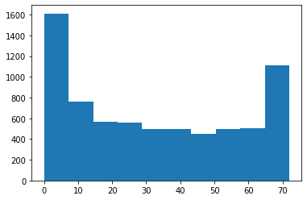

```python
# Thus the outliers for tenure is below 9 and above 55. Though right skewed, the mean is close to the median, and the maximum value
# is 72, which is not times of the 75% quantile. Thus, there is no sign that we should delete the outliers.

plt.hist(df['tenure'])

# From the histogram we can see that many observations are distributed at the two extreme values, so we cannot drop them.
```

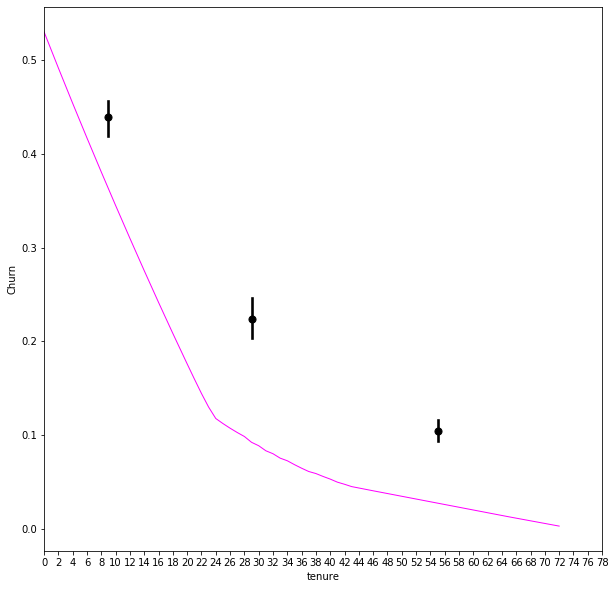

```python
# let's use a lowess line to see if there is a cutoff point at which churn rate is low
f, ax = plt.subplots(figsize=(10, 10))
tenPlot=sns.regplot(df['tenure'], df['Churn'], lowess=True, color="black", x_bins=3,
            line_kws={"color":"magenta", "linewidth":1},ax=ax)
listto80=[]
for i in range(0,80,2):
    listto80.append(i)


tenPlot.set(xticks=listto80)
```

```python
# We cab see that the rate of decreasing changes dramatically after the tenure goes up higher than 24, so we set a categorical variable
# To indicate whether the tenure is over 24
df['tenure over 24']=0
df.loc[df['tenure']>24,['tenure over 24']]=1
df=df.assign(TO24INT=df['tenure']*df['tenure over 24'])
```

```python
df['MonthlyCharges'].describe()
```

```
count    7043.000000
mean       64.761692
std        30.090047
min        18.250000
25%        35.500000
50%        70.350000
75%        89.850000
max       118.750000
Name: MonthlyCharges, dtype: float64
```

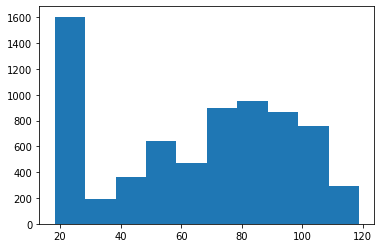

```python
#Still, though left-skewed,the mean is colse to the median, and the maximum value is not extreme, so we there is no sign that we should drop the outliers
plt.hist(df['MonthlyCharges'])
# Still, many observations are distributed at the min value, so we should not drop them
```

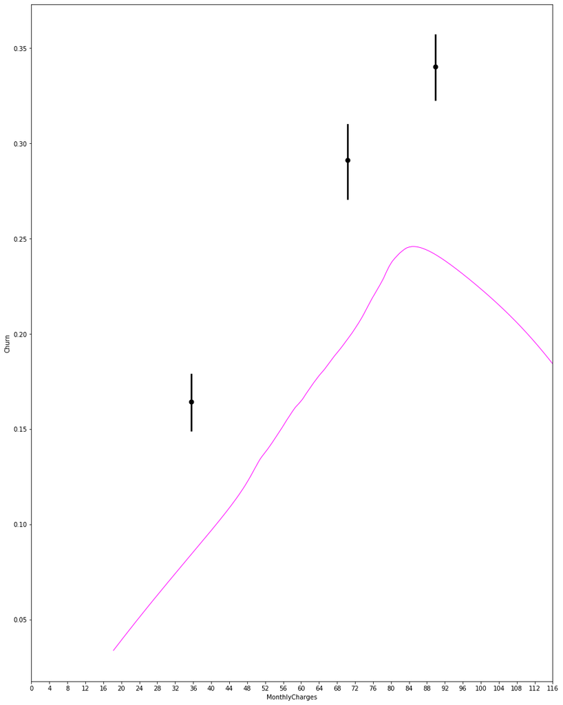

```python
# let's use a lowess line to see if there is a cutoff point at which churn rate is low
f, ax = plt.subplots(figsize=(15, 20))
tenPlot=sns.regplot(df['MonthlyCharges'], df['Churn'], lowess=True, color="black", x_bins=3,
            line_kws={"color":"magenta", "linewidth":1},ax=ax)
listto120=[]
for i in range(0,120,4):
    listto120.append(i)


tenPlot.set(xticks=listto120)
```

```python
# Again, we should set a categorical variable indicating that the monthly charges is over 84
# Because the churn rate increases with the MonthlyCharges before it reaches 84, then decreases
df['month over 84']=0
df.loc[df['MonthlyCharges']>84,['month over 84']]=1
df=df.assign(MON84INT=df['MonthlyCharges']*df['month over 84'])
```

```
count    7043.000000
mean     2279.581350
std      2264.729447
min         0.000000
25%       394.000000
50%      1393.600000
75%      3786.100000
max      8550.000000
Name: TotalCharges, dtype: float64
```

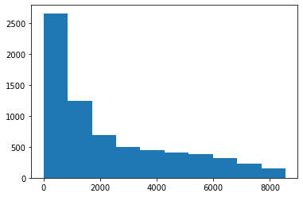

```python
print(df['TotalCharges'].describe())
plt.hist(df['TotalCharges'])
#There is no need to drop outliers as there is no one outlier substantially different from its closet observation
```

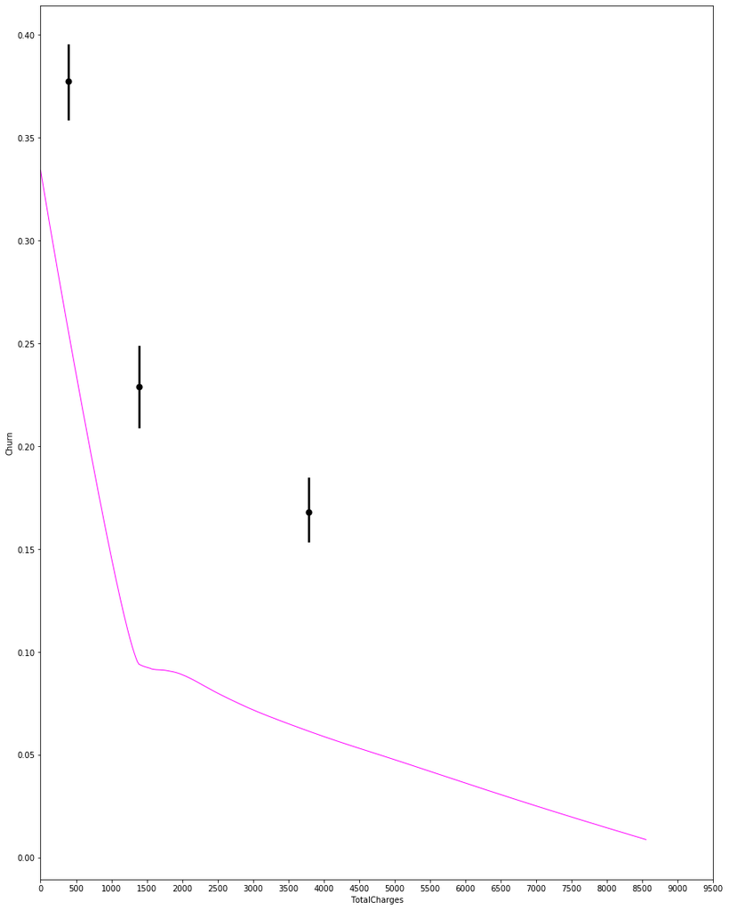

```python
# Again, let's check whether there is a cutoff point in the total charges
f, ax = plt.subplots(figsize=(15, 20))
tenPlot=sns.regplot(df['TotalCharges'], df['Churn'], lowess=True, color="black", x_bins=3,
            line_kws={"color":"magenta", "linewidth":1},ax=ax)
listto10000=[]
for i in range(0,10000,500):
    listto10000.append(i)


tenPlot.set(xticks=listto10000)
```

```python
# We can see the rate of decreasing changed at 1500, so we set a categorical variable there
df['total over 1500']=0
df.loc[df['TotalCharges']>1500,['total over 1500']]=1
df=df.assign(TOCH1500=df['TotalCharges']*df['total over 1500'])
```

```python
# let's draw the correlation matrix to find out what variables or potential variables are useful by looking at the correlation
# between each variable and the target, which is the Churn rate
# URL: https://pandas.pydata.org/pandas-docs/stable/reference/api/pandas.DataFrame.corr.html
print(df.corr()['Churn'])
```

```
gender             -0.008612
SeniorCitizen       0.150889
Partner            -0.150448
Dependents         -0.164221
tenure             -0.352229
PhoneService        0.011942
MultipleLines       0.040102
OnlineSecurity     -0.171226
OnlineBackup       -0.082255
DeviceProtection   -0.066160
TechSupport        -0.164674
StreamingTV         0.063228
StreamingMovies     0.061382
PaperlessBilling    0.191825
MonthlyCharges      0.193356
TotalCharges       -0.198514
Churn               1.000000
DSL                -0.124214
Fiber optic         0.308020
oneY_contr         -0.177820
twoY_contr         -0.302253
CreCard            -0.134302
Banktran           -0.117937
Mail               -0.091683
tenure over 24     -0.309386
TO24INT            -0.326258
month over 84       0.120477
MON84INT            0.111838
total over 1500    -0.168346
TOCH1500           -0.180121
Name: Churn, dtype: float64
```

```python
# Those with correlation less than the abosolute value of 0.1 are: gender, PhoneService, MultipleLines, OnlineBackup, DeviceProtection
# StreamingTV, StreamingMovies, Mail

# Then, we exam whether we can still save some of the variables by combining them
print(df.corr()['OnlineBackup'])
# It seems like Onlinebackup and DeviceProtection are somewhat connected, so let's try to combine them by summing them and call it internet premium
df1=df.copy()
df1['int_premium']=0
df1=df1.assign(int_premium=df1['OnlineBackup']+df1['DeviceProtection'])
```

```
gender             -0.013773
SeniorCitizen       0.066572
Partner             0.141498
Dependents          0.023671
tenure              0.360277
PhoneService       -0.052312
MultipleLines       0.202237
OnlineSecurity      0.283832
OnlineBackup        1.000000
DeviceProtection    0.303546
TechSupport         0.294233
StreamingTV         0.282106
StreamingMovies     0.274501
PaperlessBilling    0.126735
MonthlyCharges      0.441780
TotalCharges        0.509754
Churn              -0.082255
DSL                 0.157884
Fiber optic         0.165651
oneY_contr          0.083722
twoY_contr          0.111400
CreCard             0.090785
Banktran            0.087004
Mail               -0.174164
tenure over 24      0.307123
TO24INT             0.351413
month over 84       0.322275
MON84INT            0.339423
total over 1500     0.437004
TOCH1500            0.508090
Name: OnlineBackup, dtype: float64
```

```python
# Then let's drop the original internet premium service columns
df1.drop(columns=['OnlineBackup','DeviceProtection'],inplace=True)
```

```python
# Let's again check the correlations between variables and the churn
df1.corr()['Churn']
```

```
gender             -0.008612
SeniorCitizen       0.150889
Partner            -0.150448
Dependents         -0.164221
tenure             -0.352229
PhoneService        0.011942
MultipleLines       0.040102
OnlineSecurity     -0.171226
TechSupport        -0.164674
StreamingTV         0.063228
StreamingMovies     0.061382
PaperlessBilling    0.191825
MonthlyCharges      0.193356
TotalCharges       -0.198514
Churn               1.000000
DSL                -0.124214
Fiber optic         0.308020
oneY_contr         -0.177820
twoY_contr         -0.302253
CreCard            -0.134302
Banktran           -0.117937
Mail               -0.091683
tenure over 24     -0.309386
TO24INT            -0.326258
month over 84       0.120477
MON84INT            0.111838
total over 1500    -0.168346
TOCH1500           -0.180121
int_premium        -0.091921
Name: Churn, dtype: float64
```

```python
#It is not working, so we drop the combining term
df1.drop(columns=['int_premium'],inplace=True)
# Next, let's work on the streaming services. Though they require internet, we did not add them up previously as they have positive
# correlation with churn rate, but those premium internet services have negative relationships, thus we cannot combine them together
df1.corr()['StreamingTV']
# As we can see, StreamingTV has high correlation with StreamingMovies
```

```
gender             -0.008393
SeniorCitizen       0.105378
Partner             0.124666
Dependents         -0.016558
tenure              0.279756
PhoneService       -0.022574
MultipleLines       0.257152
OnlineSecurity      0.176207
TechSupport         0.278070
StreamingTV         1.000000
StreamingMovies     0.533094
PaperlessBilling    0.223841
MonthlyCharges      0.629603
TotalCharges        0.515267
Churn               0.063228
DSL                 0.016274
Fiber optic         0.329349
oneY_contr          0.061612
twoY_contr          0.072049
CreCard             0.040433
Banktran            0.046252
Mail               -0.247742
tenure over 24      0.240155
TO24INT             0.268103
month over 84       0.581667
MON84INT            0.600663
total over 1500     0.439933
TOCH1500            0.513966
Name: StreamingTV, dtype: float64
```

```python
df1['StreamingSer']=0
#Again, we combine them by adding them up
df1=df1.assign(StreamingSer=df1['StreamingTV']+df1['StreamingMovies'])
df1.drop(columns=['StreamingTV','StreamingMovies'],inplace=True)
```

```python
df1.corr()['Churn']
```

```
gender             -0.008612
SeniorCitizen       0.150889
Partner            -0.150448
Dependents         -0.164221
tenure             -0.352229
PhoneService        0.011942
MultipleLines       0.040102
OnlineSecurity     -0.171226
TechSupport        -0.164674
PaperlessBilling    0.191825
MonthlyCharges      0.193356
TotalCharges       -0.198514
Churn               1.000000
DSL                -0.124214
Fiber optic         0.308020
oneY_contr         -0.177820
twoY_contr         -0.302253
CreCard            -0.134302
Banktran           -0.117937
Mail               -0.091683
tenure over 24     -0.309386
TO24INT            -0.326258
month over 84       0.120477
MON84INT            0.111838
total over 1500    -0.168346
TOCH1500           -0.180121
StreamingSer        0.071162
Name: Churn, dtype: float64
```

```python
# It didn't work, so let's try making it a binary representing whether the observation subscribed streaming service
df1.loc[df1['StreamingSer']>0,['StreamingSer']]=1
```

```python
print(df1.corr()['Churn'])
```

```
gender             -0.008612
SeniorCitizen       0.150889
Partner            -0.150448
Dependents         -0.164221
tenure             -0.352229
PhoneService        0.011942
MultipleLines       0.040102
OnlineSecurity     -0.171226
TechSupport        -0.164674
PaperlessBilling    0.191825
MonthlyCharges      0.193356
TotalCharges       -0.198514
Churn               1.000000
DSL                -0.124214
Fiber optic         0.308020
oneY_contr         -0.177820
twoY_contr         -0.302253
CreCard            -0.134302
Banktran           -0.117937
Mail               -0.091683
tenure over 24     -0.309386
TO24INT            -0.326258
month over 84       0.120477
MON84INT            0.111838
total over 1500    -0.168346
TOCH1500           -0.180121
StreamingSer        0.085200
Name: Churn, dtype: float64
```

```python
#Still, it didn't work, so we will drop it.
#Also, PhoneService, multiplelines, gender, and Mail have low correlation with Churn, with the cutoff line of absolute value of 0.1

df1.drop(columns=['StreamingSer','PhoneService', 'gender','MultipleLines','Mail'],inplace=True)
```

```python
df1.corr()['Churn']
```

```
SeniorCitizen       0.150889
Partner            -0.150448
Dependents         -0.164221
tenure             -0.352229
OnlineSecurity     -0.171226
TechSupport        -0.164674
PaperlessBilling    0.191825
MonthlyCharges      0.193356
TotalCharges       -0.198514
Churn               1.000000
DSL                -0.124214
Fiber optic         0.308020
oneY_contr         -0.177820
twoY_contr         -0.302253
CreCard            -0.134302
Banktran           -0.117937
tenure over 24     -0.309386
TO24INT            -0.326258
month over 84       0.120477
MON84INT            0.111838
total over 1500    -0.168346
TOCH1500           -0.180121
Name: Churn, dtype: float64
```

```
(0, 28)
```

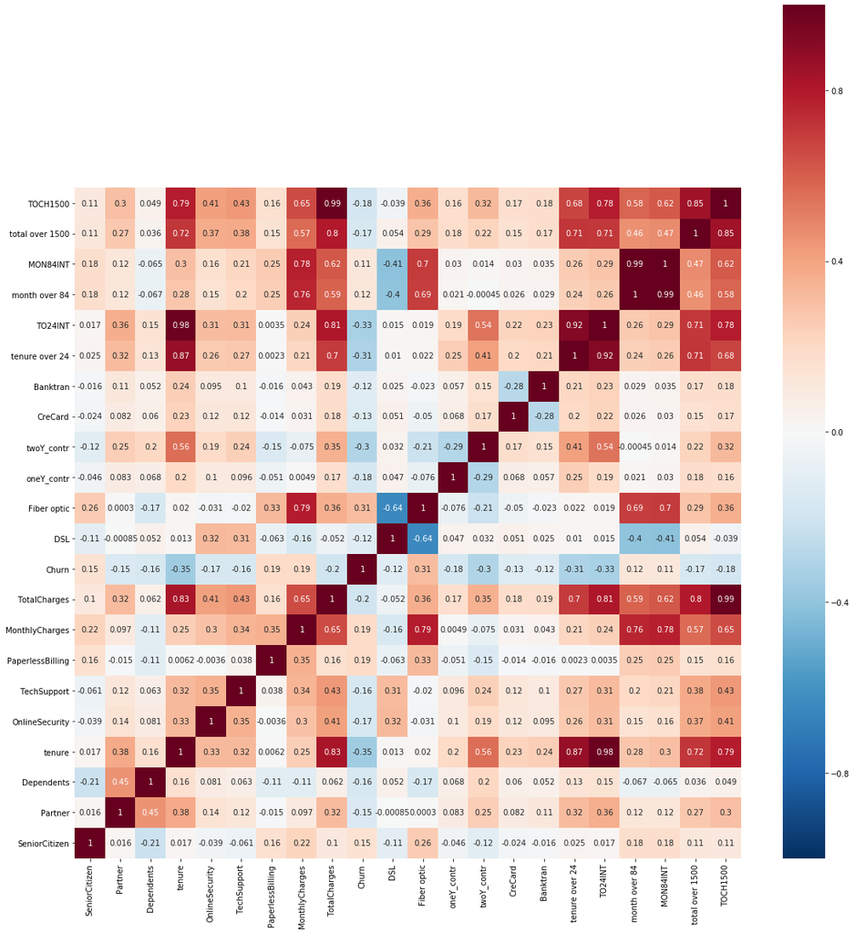

```python
# Let's find out all highly correlated pairs remaining

plt.subplots(1, 1, figsize=(19, 20))
sns.heatmap(df1.corr(),
            cmap='RdBu_r', vmin=-1, vmax=1,annot=True)

plt.ylim(0,28)
```

### Part 2: Descriptive machine learning analysis

```python
# Though some variables are highly correlated, we will first try principal components analysis, which would mitigate this disadvantage
# First, let's build another dataframe for principal component analysis
df2=df1.copy()
```

```python
# Let's first do a train-test split
X2=df2.drop(columns=['Churn'])
y2=df2[['Churn']]
X_train2, X_test2, y_train2, y_test2 = train_test_split(X2, y2, test_size=0.2,random_state=1)
```

```python
# First let's conduct a Bartlett test and KMO test to see if we can do the principal component analysis
chi_square_value,p_value=calculate_bartlett_sphericity(X_train2)
print(chi_square_value, p_value)
kmo_all,kmo_model=calculate_kmo(X_train2)
print(kmo_model)
```

```
147307.0259850198 0.0
0.6178158986151963
```

```python
# The tests are past, we can do PCA on the dataset
# Then let's conduct a pca on it, first we need to know the optimal number of components
pca1 = decomposition.PCA(n_components=0.9)
pipe2 = Pipeline([('scaler', StandardScaler()),
         ('reducer', pca1)])
X21=pipe2.fit_transform(X_train2)
```

```python
print(pca1.explained_variance_ratio_.cumsum())
```

```
[0.33183088 0.49583808 0.57040959 0.63144856 0.6905945  0.74906963
 0.79624237 0.8357541  0.86670599 0.89537735 0.91842307]
```

```python
fa=FactorAnalyzer(rotation=None,n_factors=6)
pipe2 = Pipeline([('scaler', StandardScaler()),
         ('reducer', fa)])

X22=pipe2.fit_transform(X_train2)
```

```python
# Let's set a descriptor to the factors by looking at the factor loadings
loadingsDF=pd.DataFrame(fa.loadings_,index=list(X_train2.columns), columns=['Factor 1','Factor 2','Factor 3','Factor 4','Factor 5','Factor 6'])
loadingsDF
```

|  | Factor 1 | Factor 2 | Factor 3 | Factor 4 | Factor 5 | Factor 6 |
| --- | --- | --- | --- | --- | --- | --- |
| SeniorCitizen | 0.119515 | -0.241371 | 0.051698 | -0.005843 | -0.124223 | -0.024480 |
| Partner | 0.336107 | 0.229366 | -0.232347 | -0.044593 | 0.258328 | -0.042005 |
| Dependents | 0.087824 | 0.375421 | -0.477119 | -0.059987 | 0.778721 | -0.100569 |
| tenure | 0.845828 | 0.434318 | -0.114179 | -0.016743 | -0.177521 | -0.106483 |
| OnlineSecurity | 0.389649 | 0.184743 | 0.300472 | -0.025879 | 0.180349 | 0.141731 |
| TechSupport | 0.410403 | 0.158294 | 0.312395 | -0.016865 | 0.182892 | 0.199585 |
| PaperlessBilling | 0.175638 | -0.290589 | 0.101442 | -0.000486 | 0.019840 | 0.020805 |
| MonthlyCharges | 0.684026 | -0.583681 | 0.222660 | -0.013865 | 0.191741 | 0.153185 |
| TotalCharges | 0.964147 | 0.029664 | 0.072782 | -0.027704 | -0.001717 | 0.006138 |
| DSL | -0.109832 | 0.536456 | 0.657241 | -0.101238 | 0.231369 | 0.167740 |
| Fiber optic | 0.414751 | -0.793525 | -0.172990 | 0.043232 | -0.005967 | -0.014795 |
| oneY_contr | 0.159970 | 0.098825 | 0.163573 | -0.054545 | 0.077909 | -0.470745 |
| twoY_contr | 0.372806 | 0.538287 | -0.380227 | 0.089448 | -0.177852 | 0.633042 |
| CreCard | 0.200756 | 0.197339 | 0.094900 | 0.945963 | 0.073438 | -0.080998 |
| Banktran | 0.192544 | 0.130370 | -0.053912 | -0.346280 | -0.065282 | 0.023709 |
| tenure over 24 | 0.757305 | 0.387145 | -0.075874 | -0.028403 | -0.188149 | -0.239876 |
| TO24INT | 0.842096 | 0.442478 | -0.116015 | -0.021837 | -0.212314 | -0.134334 |
| month over 84 | 0.655770 | -0.593706 | -0.085105 | 0.027590 | 0.108487 | 0.082926 |
| MON84INT | 0.681156 | -0.592045 | -0.085981 | 0.026219 | 0.107326 | 0.084338 |
| total over 1500 | 0.836390 | 0.067833 | 0.170297 | -0.058165 | -0.016336 | -0.094308 |
| TOCH1500 | 0.952512 | 0.013729 | 0.107878 | -0.037698 | 0.001794 | 0.001936 |

### Factor descriptor:

##### Factor 1: Dedication and loyalty: This factor measures how much phone service tenure term and money a customer invest in the company.

##### Factor 2: Frugal stickerness: This factor captures a trait of observations that sticks with the company for a long time but spend little on services.

##### Factor 3: DSL loneliness: This factor exhibits a trait of subscribing DSL service, having no dependants, and needing tech/security support.

##### Factor 4: Credit card lover: This factor showing that one prefer to pay by credit card.

##### Factor 5: Family provider: This factor shows one tend to have dependants and partner.

##### Factor 6: Extreme terms signers: This factor captures a trait that prone to signs either a one-month contract or a 2-year contract

```python
# Then let's put in the algorithms, we first want to know the coefficients of the factors, so we would first use logistic regression
from sklearn.linear_model import LogisticRegression
from sklearn.model_selection import RandomizedSearchCV
import warnings
warnings.filterwarnings("ignore")
pipelogi=Pipeline([('classifier', LogisticRegression(solver='lbfgs'))])
search_space = [{'classifier': [LogisticRegression(solver='lbfgs')],
                 'classifier__C':[0.01,0.1,0.2,0.3,0.4,0.5,0.6,0.7,0.8,0.9,1,1.2,1.4,1.6,1.8,2,3,4,5,7,9,10],
                'classifier__solver':['liblinear', 'saga','lbfgs']}]
clfLogi=RandomizedSearchCV(pipelogi,search_space,cv=10,n_iter=100)
```

```python
Logi_model=clfLogi.fit(X22,y_train2)
print(Logi_model)
X22test=pipe2.transform(X_test2)
```

[output not shown]

```python
Logi_model=LogisticRegression(C=0.01, class_weight=None, dual=False,
                                    fit_intercept=True, intercept_scaling=1,
                                    l1_ratio=None, max_iter=100,
                                    multi_class='auto', n_jobs=None,
                                    penalty='l2', random_state=None,
                                    solver='saga', tol=0.0001, verbose=0,
                                    warm_start=False)
Logi_model.fit(X22,y_train2)
```

```
LogisticRegression(C=0.01, class_weight=None, dual=False, fit_intercept=True,
                   intercept_scaling=1, l1_ratio=None, max_iter=100,
                   multi_class='auto', n_jobs=None, penalty='l2',
                   random_state=None, solver='saga', tol=0.0001, verbose=0,
                   warm_start=False)
```

```
Error rate: 0.200
```

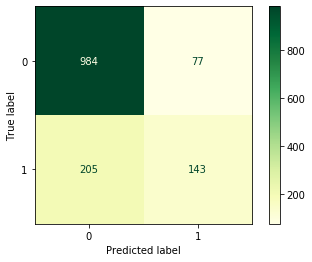

```python
from sklearn.metrics import plot_confusion_matrix
print(f"Error rate: {1 - Logi_model.score(X22test, y_test2):.3f}")
plot_confusion_matrix(Logi_model, X22test, y_test2, cmap='YlGn', values_format='.0f');
```

```python
# The accuracy is 80%, which is not bad, and the false positive rate is low comparing to its false negative rate
# Overall, this model is acceptable for descriptive purpose, and let's see its coefficients
pd.DataFrame(Logi_model.coef_, columns=['Factor 1','Factor 2','Factor 3','Factor 4','Factor 5','Factor 6'])
```

|  | Factor 1 | Factor 2 | Factor 3 | Factor 4 | Factor 5 | Factor 6 |
| --- | --- | --- | --- | --- | --- | --- |
| 0 | -0.458 | -1.129622 | 0.166936 | -0.049821 | 0.12834 | -0.008645 |

### Thus we can see that Factor 2 is the most important sector, with Factor 1 second to it. The rest do not have a great influence on Churn rate.

### Next, let's see the importance of the original features (features prior to PCA)

```python
# First reset X and y
X1=df1.drop(columns=['Churn'])
y1=df1['Churn']
X_train1, X_test1, y_train1, y_test1 = train_test_split(X1, y1, test_size=0.2, random_state=7)
```

```python
from sklearn.ensemble import RandomForestClassifier
pipe3 = Pipeline([('scaler', StandardScaler()),
            ('classifier',LogisticRegression(solver='lbfgs'))     ])
search_space2 = [{'classifier': [LogisticRegression(solver='lbfgs')],
                 'classifier__C':[0.01,0.1,0.2,0.3,0.4,0.5,0.6,0.7,0.8,0.9,1,1.2,1.4,1.6,1.8,2,3,4,5,7,9,10],
                'classifier__solver':['liblinear', 'saga','lbfgs']},
                {'classifier':[RandomForestClassifier()],
                'classifier__max_depth':[1,2,3,4,5,6,7,8,9,10,11,12,13,14,15,16,None],
                'classifier__n_estimators':[100,200]}]
clfdescrip=RandomizedSearchCV(pipe3,search_space2,cv=10,n_iter=20)
```

```python
# Let's see which algorithm ended up used
clfdescrip.fit(X_train1,y_train1)
```

[output not shown]

```
Error rate: 0.187
```

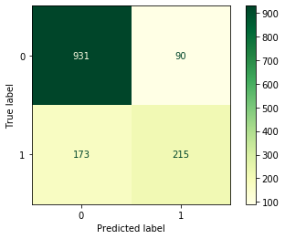

```python
# So we ended up using logistic regression again, let's check the performance
print(f"Error rate: {1 - clfdescrip.best_estimator_.score(X_test1, y_test1):.3f}")
plot_confusion_matrix(clfdescrip.best_estimator_, X_test1, y_test1, cmap='YlGn', values_format='.0f');
```

```python
clfdescrip.best_estimator_
```

```
Pipeline(memory=None,
         steps=[('scaler',
                 StandardScaler(copy=True, with_mean=True, with_std=True)),
                ('classifier',
                 LogisticRegression(C=7, class_weight=None, dual=False,
                                    fit_intercept=True, intercept_scaling=1,
                                    l1_ratio=None, max_iter=100,
                                    multi_class='auto', n_jobs=None,
                                    penalty='l2', random_state=None,
                                    solver='liblinear', tol=0.0001, verbose=0,
                                    warm_start=False))],
         verbose=False)
```

```python
# The accuracy is 81.3%, which is not bad, and the false positive rate is low comparing to its false negative rate
# Overall, this model is acceptable for descriptive purpose, and let's see its coefficients
model2=LogisticRegression(C=7, class_weight=None, dual=False,
                                    fit_intercept=True, intercept_scaling=1,
                                    l1_ratio=None, max_iter=100,
                                    multi_class='auto', n_jobs=None,
                                    penalty='l2', random_state=None,
                                    solver='liblinear', tol=0.0001, verbose=0,
                                    warm_start=False)
model2.fit(StandardScaler(copy=True, with_mean=True, with_std=True).fit_transform(X_train1),y_train1)
pd.set_option('display.max_columns', None)
pd.DataFrame(model2.coef_, columns=X_train1.columns)
```

|  | SeniorCitizen | Partner | Dependents | tenure | OnlineSecurity | TechSupport | PaperlessBilling | MonthlyCharges | TotalCharges | DSL | Fiber optic | oneY_contr | twoY_contr | CreCard | Banktran | tenure over 24 | TO24INT | month over 84 | MON84INT | total over 1500 | TOCH1500 |
| --- | --- | --- | --- | --- | --- | --- | --- | --- | --- | --- | --- | --- | --- | --- | --- | --- | --- | --- | --- | --- | --- |
| 0 | 0.091742 | 0.014146 | -0.077732 | -2.605013 | -0.2467 | -0.178881 | 0.174144 | -0.173058 | 0.969039 | 0.633721 | 1.049655 | -0.288498 | -0.669438 | -0.098065 | -0.070221 | -0.950066 | 2.697106 | -1.562068 | 1.899466 | 0.507873 | -1.326188 |

### So from the result we can see that Fiber optic, tenure, interaction between Monthly charges over 84 and MonthlyCharges, Monthly charges over 84, and interaction between total over 1500 and TotalCharges are important features that determine whether one would churn.

## Part 3: Predictive modelling

The predictive modelling part has two parts, the first one is to build an algorithm by features created, the second one is to use principal components, or factors.

```python
# First, according to the result in the previous section, we need to conduct another feature engineering process to better build
# a predictive model
df3=df1.copy()
df3.drop(columns=['SeniorCitizen','Partner','Dependents','CreCard','Banktran'],inplace=True)
#df4 is a less-dimensionality dataset
df4=df3.drop(columns=['TechSupport','PaperlessBilling','MonthlyCharges','OnlineSecurity'])
```

```python
df3X=df3.drop(columns=['Churn'])
df3y=df3['Churn']

df4X=df4.drop(columns=['Churn'])
df4y=df4['Churn']
```

```python
X_traindf3, X_testdf3, y_traindf3, y_testdf3 = train_test_split(df3X, df3y, test_size=0.2,random_state=1)

X_traindf4, X_testdf4, y_traindf4, y_testdf4 = train_test_split(df4X, df4y, test_size=0.2,random_state=1)
```

```python
# Algorithms(classifier) to be used: logistics regression, random forest, XGboost, LGBM, support vector, knn, voting classifier, stacking model
# Logistics first
Logipipe13=Pipeline([('scaler', StandardScaler()),
            ('classifier',LogisticRegression(solver='lbfgs'))     ])
search_space_logi13 = [{'classifier': [LogisticRegression(solver='lbfgs')],
                 'classifier__C':[0.01,0.1,0.2,0.3,0.4,0.5,0.6,0.7,0.8,0.9,1,1.2,1.4,1.6,1.8,2,3,4,5,7,9,10],
                'classifier__solver':['liblinear', 'saga','lbfgs']}]
clflogi13=RandomizedSearchCV(Logipipe13,search_space_logi13,cv=10,n_iter=40)
clflogi14=RandomizedSearchCV(Logipipe13,search_space_logi13,cv=10,n_iter=40)
```

```python
clflogi13.fit(X_traindf3,y_traindf3)
clflogi14.fit(X_traindf4,y_traindf4)

print(f"Error rate for df3: {1 - clflogi13.best_estimator_.score(X_testdf3, y_testdf3):.3f}")
print(f"Error rate for df4: {1 - clflogi14.best_estimator_.score(X_testdf4, y_testdf4):.3f}")
```

```
Error rate for df3: 0.183
Error rate for df4: 0.194
```

```python
# Next comes the random forest
RFpipe13=Pipeline([('scaler', StandardScaler()),
            ('classifier',RandomForestClassifier())     ])
search_space_RF13=[{'classifier':[RandomForestClassifier()],
                'classifier__max_depth':[1,2,3,4,5,6,7,8,9,10,11,12,13,14,15,16,None],
                'classifier__n_estimators':[100,200]}]
clfRF13=RandomizedSearchCV(RFpipe13,search_space_RF13,cv=10,n_iter=10)
clfRF14=RandomizedSearchCV(RFpipe13,search_space_RF13,cv=10,n_iter=10)
```

```python
clfRF13.fit(X_traindf3,y_traindf3)
clfRF14.fit(X_traindf4,y_traindf4)
print(f"Error rate for df3: {1 - clfRF13.best_estimator_.score(X_testdf3, y_testdf3):.3f}")
print(f"Error rate for df4: {1 - clfRF14.best_estimator_.score(X_testdf4, y_testdf4):.3f}")
```

```
Error rate for df3: 0.192
Error rate for df4: 0.197
```

```python
# Then comes the XGboost, since df3 seems to be more suitable for fitting the algorithm, we will not test df4 again
import xgboost as xgb
# here we will use two models: gblinear and gbtree
XGpipe13_1=Pipeline([('scaler', StandardScaler()),
            ('classifier',xgb.XGBClassifier(booster='gblinear'))     ])
XGpipe13_2=Pipeline([('scaler', StandardScaler()),
            ('classifier',xgb.XGBClassifier())     ])
search_space_XGpipe13=[{'classifier':[xgb.XGBClassifier()],
                'classifier__max_depth':[1,2,3,4,5,6,7,8,9,10,11,None],
                'classifier__n_estimators':[100,200]}]
clfXG13=RandomizedSearchCV(XGpipe13_2,search_space_XGpipe13,cv=10,n_iter=10)
```

```python
XGpipe13_1.fit(X_traindf3,y_traindf3)
clfXG13.fit(X_traindf3,y_traindf3)
print(f"Error rate for Linear: {1 - XGpipe13_1.score(X_testdf3, y_testdf3):.3f}")
print(f"Error rate for Tree: {1 - clfXG13.best_estimator_.score(X_testdf3, y_testdf3):.3f}")
```

```
Error rate for Linear: 0.247
Error rate for Tree: 0.192
```

```python
# The next model is LGBM
import lightgbm as lgb
from lightgbm import LGBMModel,LGBMClassifier
LGpipe13=Pipeline([('scaler', StandardScaler()),
            ('classifier',LGBMClassifier())     ])
search_space_LGpipe13=[{'classifier':[LGBMClassifier()],
                'classifier__max_depth':[1,2,3,4,5,6,7,8,9,10,11,12,13,14,15,16,None],
                'classifier__n_estimators':[100,200]}]
clfLG13=RandomizedSearchCV(LGpipe13,search_space_LGpipe13,cv=10,n_iter=30)
```

```python
clfLG13.fit(X_traindf3,y_traindf3)
print(f"Error rate : {1 - clfLG13.best_estimator_.score(X_testdf3, y_testdf3):.3f}")
```

```
Error rate : 0.185
```

```python
# The next model is support vector
from sklearn.svm import SVC
SVCpipe13=Pipeline([('scaler', StandardScaler()),
            ('classifier',SVC())     ])
search_space_SVCpipe13=[{'classifier':[SVC()],
                'classifier__C':[0.05,0.1,0.15,0.2,0.3,0.5,0.8,1,1.5,2,5,10],
                'classifier__kernel':['linear', 'poly', 'rbf', 'sigmoid', 'precomputed']}]
clfSVC13=RandomizedSearchCV(SVCpipe13,search_space_SVCpipe13,cv=10,n_iter=40)
```

```python
clfSVC13.fit(X_traindf3,y_traindf3)
print(f"Error rate : {1 - clfSVC13.best_estimator_.score(X_testdf3, y_testdf3):.3f}")
```

```
Error rate : 0.194
```

```python
# The next model is knn
from sklearn.model_selection import GridSearchCV
from sklearn.neighbors import KNeighborsRegressor
knnpipe13=Pipeline([('scaler', StandardScaler()),
            ('classifier',KNeighborsRegressor(algorithm='ball_tree'))     ])
search_space_knnpipe13=[{'classifier':[KNeighborsRegressor(algorithm='ball_tree')],
                'classifier__n_neighbors':[1,2,3,4,5,6,7,8,9,10,11,12,13,20,30,40,50,60,70,80,100]}]
clfknn13=GridSearchCV(knnpipe13,search_space_knnpipe13,cv=10)
```

```python
clfknn13.fit(X_traindf3,y_traindf3)
print(f"Error rate : {1 - clfknn13.best_estimator_.score(X_testdf3, y_testdf3):.3f}")
```

```
Error rate : 0.711
```

```python
# Knn is a disaster in this case, and the voting classifier would be composed of logistic regression, LGBM, and RandomForest
from sklearn.ensemble import RandomForestClassifier, VotingClassifier

clf_vote = VotingClassifier(
    estimators=[('logistics', clflogi13.best_estimator_), ('LGBM', clfLG13.best_estimator_), ('RF', clfRF13.best_estimator_),('SVC',clfSVC13.best_estimator_)]
)

clf_vote.fit(X_traindf3,y_traindf3)
print(f"Error rate : {1 - clf_vote.score(X_testdf3, y_testdf3):.3f}")
```

```
Error rate : 0.182
```

```python
# Naive bayes serves as an implemental algorithm for stacking
from sklearn.naive_bayes import MultinomialNB
clfNB=MultinomialNB()
clfNB.fit(X_traindf3,y_traindf3)
print(f"Error rate : {1 - clfNB.score(X_testdf3, y_testdf3):.3f}")
```

```
Error rate : 0.398
```

```python
# Then we will build a stacking algorithm
# First layer:
Logistics=clflogi13.best_estimator_.predict(X_traindf3)
LGBM=clfLG13.best_estimator_.predict(X_traindf3)
RForest=clfRF13.best_estimator_.predict(X_traindf3)
XGB=clfXG13.best_estimator_.predict(X_traindf3)
NB=clfNB.predict(X_traindf3)
#KNN=clfknn13.predict(X_traindf3)
SVC=clfSVC13.best_estimator_.predict(X_traindf3)
# Making it a dataframe
X_train = pd.DataFrame({
'pred_logi': Logistics,
'pred_lgbm': LGBM,
'pred_RF': RForest,
'pred_XGB': XGB,
    'pred_NB':NB,
    #"pred_knn":KNN,
    'pred_svc':SVC
}, index=X_traindf3.index)
# Transforming for test set
Logistics_test=clflogi13.best_estimator_.predict(X_testdf3)
LGBM_test=clfLG13.best_estimator_.predict(X_testdf3)
RForest_test=clfRF13.best_estimator_.predict(X_testdf3)
XGB_test=clfXG13.best_estimator_.predict(X_testdf3)
NB_test=clfNB.predict(X_testdf3)
#KNN_test=clfknn13.predict(X_testdf3)
SVC_test=clfSVC13.best_estimator_.predict(X_testdf3)
# Making it a dataframe
X_test = pd.DataFrame({
'pred_logi': Logistics_test,
'pred_lgbm': LGBM_test,
'pred_RF': RForest_test,
'pred_XGB': XGB_test,
   'pred_NB':NB_test,
    #"pred_knn":KNN_test,
    'pred_svc':SVC_test
}, index=X_testdf3.index)

# Use pipeline to find out the best second-layer algorithm, or the anchor. Candidates are logistics regression classifier,
# lgbm, and xGBoost

anchorpipe=Pipeline([('scaler', StandardScaler()),
            ('classifier',LGBMClassifier())     ])
search_space_anchorpipe=[{'classifier':[LGBMClassifier()],
                'classifier__max_depth':[1,2,3,4,5,6,7,8,9,10,11,12,13,14,15,16,None],
                'classifier__n_estimators':[100,200]},
                       {'classifier': [LogisticRegression(solver='lbfgs')],
                 'classifier__C':[0.01,0.1,0.2,0.3,0.4,0.5,0.6,0.7,0.8,0.9,1,1.2,1.4,1.6,1.8,2,3,4,5,7,9,10],
                'classifier__solver':['liblinear', 'saga','lbfgs']} ,
                        {'classifier':[xgb.XGBClassifier()],
                'classifier__max_depth':[1,2,3,4,5,6,7,8,9,10,11,None],
                'classifier__n_estimators':[100,200]}]
clf_stacking=RandomizedSearchCV(anchorpipe,search_space_anchorpipe,cv=10,n_iter=80)
```

```python
clf_stacking.fit(X_train,y_traindf3)
print(f"Error rate : {1 - clf_stacking.best_estimator_.score(X_test, y_testdf3):.3f}")
```

```
Error rate : 0.183
```

In the path 1, the voting classfier performs the best.

### Part 3 (path 2): Building algorithm basing on PCA

```python
# To gain more predictive power, I will include 8 components/factors
FA=FactorAnalyzer(rotation=None,n_factors=8)
pipeFA = Pipeline([('scaler', StandardScaler()),
         ('reducer', FA)])

train_X=pipeFA.fit_transform(X_train2)
test_X=pipeFA.transform(X_test2)
```

```python
# Logistics first
clflogi13.fit(train_X,y_train2)


print(f"Error rate for df3: {1 - clflogi13.best_estimator_.score(test_X, y_test2):.3f}")
```

```
Error rate for df3: 0.194
```

```python
# Then Random Forest
clfRF13.fit(train_X,y_train2)
```

[output not shown]

```
Error rate for df3: 0.181
```

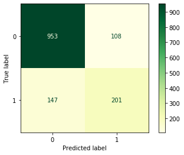

```python
print(f"Error rate for df3: {1 - clfRF13.best_estimator_.score(test_X, y_test2):.3f}")
plot_confusion_matrix(clfRF13.best_estimator_, test_X, y_test2, cmap='YlGn', values_format='.0f');
```

```python
# XGBoost
clfXG13.fit(train_X,y_train2)

print(f"Error rate for Tree: {1 - clfXG13.best_estimator_.score(test_X, y_test2):.3f}")
```

```
Error rate for Tree: 0.186
```

```python
# LGBM
clfLG13.fit(train_X,y_train2)
print(f"Error rate : {1 - clfLG13.best_estimator_.score(test_X, y_test2):.3f}")
```

```
Error rate : 0.184
```

```python
# Support Vector
clfSVC13.fit(train_X,y_train2)
print(f"Error rate : {1 - clfSVC13.best_estimator_.score(test_X, y_test2):.3f}")
```

```
Error rate : 0.202
```

```python
# KNN
clfknn13.fit(train_X,y_train2)
print(f"Error rate : {1 - clfknn13.best_estimator_.score(test_X, y_test2):.3f}")
```

```
Error rate : 0.704
```

```python
clf_vote = VotingClassifier(
    estimators=[ ('logistics', clflogi13.best_estimator_),('LGBM', clfLG13.best_estimator_), ('RF', clfRF13.best_estimator_),('XGB',clfXG13.best_estimator_)]
)
```

```python
# Voting classifier
clf_vote.fit(train_X,y_train2)
print(f"Error rate : {1 - clf_vote.score(test_X, y_test2):.3f}")
```

```
Error rate : 0.184
```

```python
clflogi13.best_estimator_.classes_
```

```
array([0, 1], dtype=int64)
```

```python
# Then we will build a stacking algorithm
# First layer:
Logistics=clflogi13.best_estimator_.predict(train_X)
LGBM=clfLG13.best_estimator_.predict(train_X)
RForest=clfRF13.best_estimator_.predict(train_X)
XGB=clfXG13.best_estimator_.predict(train_X)
#NB=clfNB.predict(X_traindf3)
#KNN=clfknn13.predict(X_traindf3)
SVC=clfSVC13.best_estimator_.predict(train_X)
# Making it a dataframe
X_train = pd.DataFrame({
'pred_logi': Logistics,
'pred_lgbm': LGBM,
'pred_RF': RForest,
'pred_XGB': XGB,
    #'pred_NB':NB,
    #"pred_knn":KNN,
    'pred_svc':SVC
}, index=X_train2.index)
# Transforming for test set
Logistics_test=clflogi13.best_estimator_.predict(test_X)
LGBM_test=clfLG13.best_estimator_.predict(test_X)
RForest_test=clfRF13.best_estimator_.predict(test_X)
XGB_test=clfXG13.best_estimator_.predict(test_X)
#NB_test=clfNB.predict(X_testdf3)
#KNN_test=clfknn13.predict(X_testdf3)
SVC_test=clfSVC13.best_estimator_.predict(test_X)
# Making it a dataframe
X_test = pd.DataFrame({
'pred_logi': Logistics_test,
'pred_lgbm': LGBM_test,
'pred_RF': RForest_test,
'pred_XGB': XGB_test,
   #'pred_NB':NB_test,
    #"pred_knn":KNN_test,
    'pred_svc':SVC_test
}, index=X_test2.index)

# Use pipeline to find out the best second-layer algorithm, or the anchor. Candidates are logistics regression classifier,
# lgbm, and xGBoost

anchorpipe=Pipeline([('scaler', StandardScaler()),
            ('classifier',LGBMClassifier())     ])
search_space_anchorpipe=[{'classifier':[LGBMClassifier()],
                'classifier__max_depth':[1,2,3,4,5,6,7,8,9,10,11,12,13,14,15,16,None],
                'classifier__n_estimators':[100,200]},
                       {'classifier': [LogisticRegression(solver='lbfgs')],
                 'classifier__C':[0.01,0.1,0.2,0.3,0.4,0.5,0.6,0.7,0.8,0.9,1,1.2,1.4,1.6,1.8,2,3,4,5,7,9,10],
                'classifier__solver':['liblinear', 'saga','lbfgs']} ,
                        {'classifier':[xgb.XGBClassifier()],
                'classifier__max_depth':[1,2,3,4,5,6,7,8,9,10,11,None],
                'classifier__n_estimators':[100,200]},
                        {'classifier':[RandomForestClassifier()],
                'classifier__max_depth':[1,2,3,4,5,6,7,8,9,10,11,12,13,14,15,16,None],
                'classifier__n_estimators':[100,200]}]
clf_stacking=RandomizedSearchCV(anchorpipe,search_space_anchorpipe,cv=10,n_iter=80)
```

```python
# Stacking model
clf_stacking.fit(X_train,y_train2)
```

[output not shown]

```python
print(f"Error rate : {1 - clf_stacking.best_estimator_.score(X_test, y_test2):.3f}")
```

```
Error rate : 0.181
```

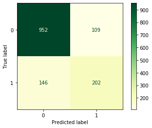

```python
plot_confusion_matrix(clf_stacking.best_estimator_, X_test, y_test2, cmap='YlGn', values_format='.0f');
```

Since the The Stacking model in path 2 gives the best performance, out final predictive model would be: First transforming the data using PCA with 8 components and then use the Stacking model to predict it. The accuracy rate given the test set is around 81.9%, and given the whole dataset to train, the accuracy rate is expected to improve. Besides its accuracy, another merit for this model is that it has a low false negative rate comparing to its sensitivity.